# Potential Client Detection

An ANN aproach for customer Classification.

Josep R.C. https://www.linkedin.com/in/josep%F0%9F%8C%AB-roman-cardell-414880184/ (UIB Student)https://www.uib.cat/  
2021-06-04

**Libraries**

```r
library(readr)
library(tidyverse)
library(magrittr)
library(caret)
library(neuralnet)

library(ggplot2)
library(rmarkdown)
```

# About the data

The dataset, **Bank Marketing**, is related with direct marketing campaigns of a Portuguese banking institution. The marketing campaigns were based on phone calls. Often, more than one contact to the same client was required, in order to access if the product (bank term deposit) would be (or not) subscribed. The classification goal is to **predict if the client will subscribe** a term deposit.

Data was recorded from May 2008 to November 2010.

## Feature Selection

From my lack of knowledge in terms of *Term Deposits* I first did a bit of research in order to better understand the matter of analysis and thus, be able to efficiently select the optimum variables. I focused my research on [Investopedia term deposit article](https://www.investopedia.com/terms/t/termdeposit.asp).

The features are divided in:

- **Personal and bank related client data**. I have decided to start with all variables as a profound description of the client is necessary in order to know if the person will be willing, or even able to invest in a term deposit.
- **Last contact data**. Regarding the last call data, I believe it can be interesting to keep the month and day in which it occurred. My hypothesis is that there is a possible by which people in general fill more confident about their money in some periods of the year or the week. Also the duration of the call can be helpful. However, I’ve decided to not use a feature which labels the call as it was done via *telephone*, *cellular* or *unkown*, as a think it’s redundant for this problem.
- Other attributes. I have kept the four variables as a description of the relation between the client and the current and previous campaigns.

For a detailed description of all features go to the [metadata](https://github.com/Josep-at-work/Predicting-Customer-Subcription-ANN/blob/main/Data/bank-names.txt) file.

# Data Wrangling

First of all, I’ve loaded the dataset and removed the *contact* feature. Then, I’ve modified some data types. I’ve transformed all binary variables into 1 and 0 instead of *yes* and *no* respectively, and all character features into factors. Both of this changes will help on the visualization tasks and the training of the model.

**Loading Data**

```r
data <- read_delim("Data/bank-full.csv", ";", escape_double = FALSE, trim_ws = TRUE)
data %<>% select(-contact)
str(data)
```

```
tibble [45,211 x 16] (S3: tbl_df/tbl/data.frame)
 $ age      : num [1:45211] 58 44 33 47 33 35 28 42 58 43 ...
 $ job      : chr [1:45211] "management" "technician" "entrepreneur" "blue-collar" ...
 $ marital  : chr [1:45211] "married" "single" "married" "married" ...
 $ education: chr [1:45211] "tertiary" "secondary" "secondary" "unknown" ...
 $ default  : chr [1:45211] "no" "no" "no" "no" ...
 $ balance  : num [1:45211] 2143 29 2 1506 1 ...
 $ housing  : chr [1:45211] "yes" "yes" "yes" "yes" ...
 $ loan     : chr [1:45211] "no" "no" "yes" "no" ...
 $ day      : num [1:45211] 5 5 5 5 5 5 5 5 5 5 ...
 $ month    : chr [1:45211] "may" "may" "may" "may" ...
 $ duration : num [1:45211] 261 151 76 92 198 139 217 380 50 55 ...
 $ campaign : num [1:45211] 1 1 1 1 1 1 1 1 1 1 ...
 $ pdays    : num [1:45211] -1 -1 -1 -1 -1 -1 -1 -1 -1 -1 ...
 $ previous : num [1:45211] 0 0 0 0 0 0 0 0 0 0 ...
 $ poutcome : chr [1:45211] "unknown" "unknown" "unknown" "unknown" ...
 $ y        : chr [1:45211] "no" "no" "no" "no" ...
```

**Summary**

```r
data$default <- ifelse(data$default == "yes", 1, 0)
data$housing <- ifelse(data$housing == "yes", 1, 0)
data$loan <- ifelse(data$loan == "yes", 1, 0)
data$y <- ifelse(data$y == "yes", 1, 0)
copy <- data #create a copy of the data
data %<>% mutate(across(c(job, marital, education, month, poutcome,
                          default, housing, loan, y), as.factor))
summary(data)
```

```
      age                 job           marital
 Min.   :18.00   blue-collar:9732   divorced: 5207
 1st Qu.:33.00   management :9458   married :27214
 Median :39.00   technician :7597   single  :12790
 Mean   :40.94   admin.     :5171
 3rd Qu.:48.00   services   :4154
 Max.   :95.00   retired    :2264
                 (Other)    :6835
     education     default      balance       housing   loan
 primary  : 6851   0:44396   Min.   : -8019   0:20081   0:37967
 secondary:23202   1:  815   1st Qu.:    72   1:25130   1: 7244
 tertiary :13301             Median :   448
 unknown  : 1857             Mean   :  1362
                             3rd Qu.:  1428
                             Max.   :102127

      day            month          duration         campaign
 Min.   : 1.00   may    :13766   Min.   :   0.0   Min.   : 1.000
 1st Qu.: 8.00   jul    : 6895   1st Qu.: 103.0   1st Qu.: 1.000
 Median :16.00   aug    : 6247   Median : 180.0   Median : 2.000
 Mean   :15.81   jun    : 5341   Mean   : 258.2   Mean   : 2.764
 3rd Qu.:21.00   nov    : 3970   3rd Qu.: 319.0   3rd Qu.: 3.000
 Max.   :31.00   apr    : 2932   Max.   :4918.0   Max.   :63.000
                 (Other): 6060
     pdays          previous           poutcome     y
 Min.   : -1.0   Min.   :  0.0000   failure: 4901   0:39922
 1st Qu.: -1.0   1st Qu.:  0.0000   other  : 1840   1: 5289
 Median : -1.0   Median :  0.0000   success: 1511
 Mean   : 40.2   Mean   :  0.5803   unknown:36959
 3rd Qu.: -1.0   3rd Qu.:  0.0000
 Max.   :871.0   Max.   :275.0000
```

From the target variable we can say that only 11.7% of the clients subscribed to the term deposit.

## Missing values.

```r
data.frame("NA's" = colSums(is.na(data))) %>% paged_table()
```

|  | NA.s |
| --- | --- |
| age | 0 |
| job | 0 |
| marital | 0 |
| education | 0 |
| default | 0 |
| balance | 0 |
| housing | 0 |
| loan | 0 |
| day | 0 |
| month | 0 |

[output cut: 6 more lines]

There are no missing values in any of the features.

# Exploratory Data Analysis

Now it’s time to study the data behavior and relations, as well as detect outliers and other specific values.

## Target variable

**Target Feature**

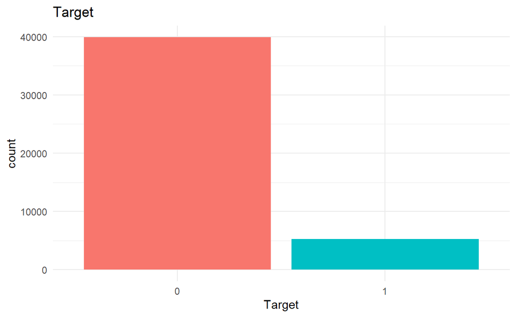

```r
data %>%
  ggplot(aes(as.factor(y), fill = as.factor(y))) +
  geom_bar() +
  theme_minimal() +
  labs(x = "Target") +
  theme(legend.position = "none") +
  ggtitle("Target")
```

**Target Feature**

```r
data.frame(prop.table(table(data$y))) %>% paged_table()
```

| Var1 | Freq |
| --- | --- |
| 0 | 0.8830152 |
| 1 | 0.1169848 |

The target data in this study is heavily unbalanced.

## Features

Starting from the fact that only a 11.7% of the contacted clients subscribed to the campaign, the following plots aim to visualize the **normalized distribution** of the target variable among all categorical features:

**Categorical Features**

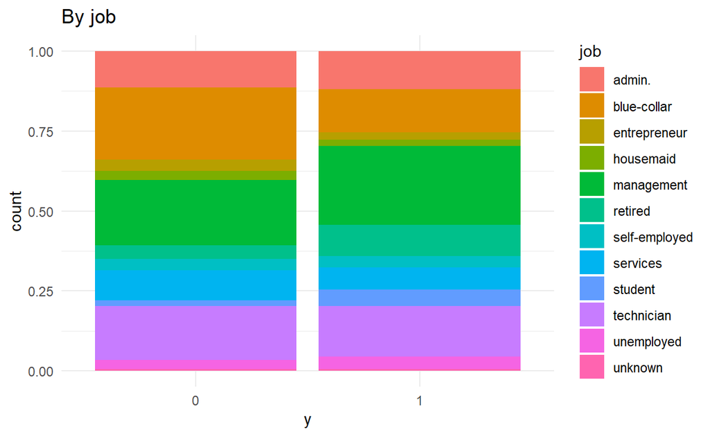

```r
data %>%
  ggplot(aes(y, fill = job)) +
  geom_bar(position = "fill") +
  theme_minimal() +
  ggtitle("By job")
```

**Categorical Features**

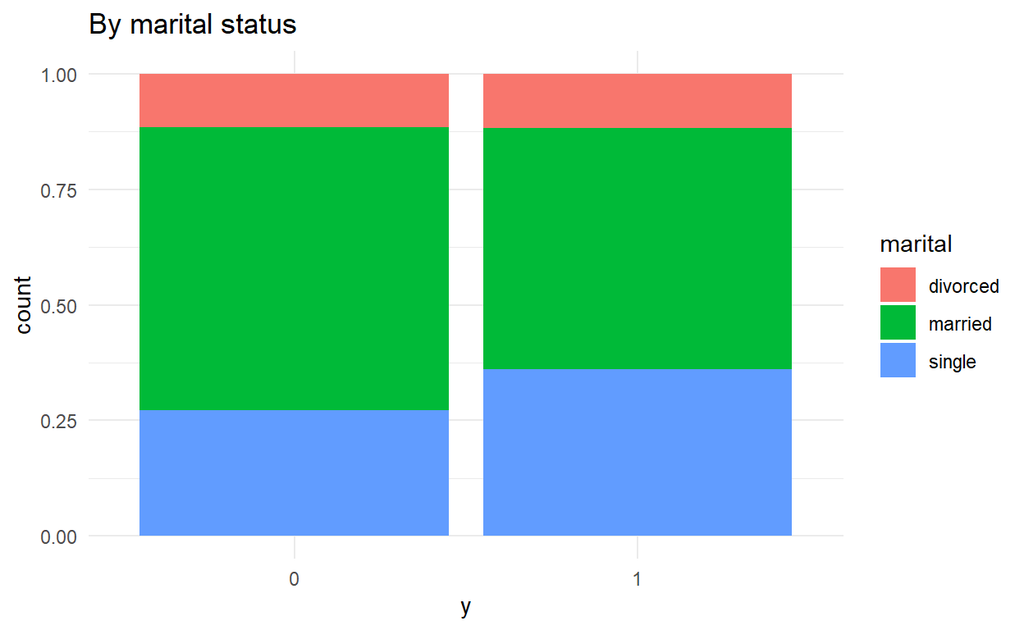

```r
data %>%
  ggplot(aes(y, fill = marital)) +
  geom_bar(position = "fill") +
  theme_minimal() +
  ggtitle("By marital status")
```

**Categorical Features**

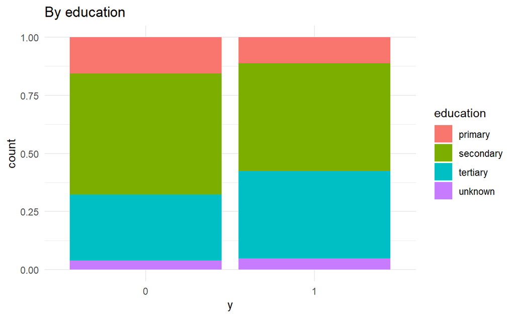

```r
data %>%
  ggplot(aes(y, fill = education)) +
  geom_bar(position = "fill") +
  theme_minimal() +
  ggtitle("By education")
```

**Categorical Features**

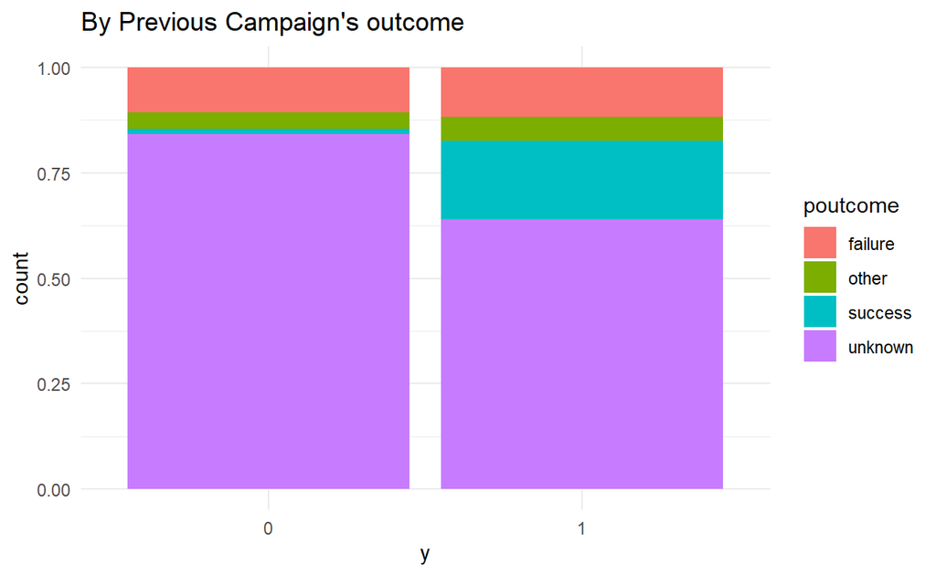

```r
data %>%
  ggplot(aes(y, fill = poutcome)) +
  geom_bar(position = "fill") +
  theme_minimal() +
  ggtitle("By Previous Campaign's outcome")
```

From these normalized stacked plots there is little to say. There isn’t much difference in the proportion of people of each category in both groups. The most relevant aspect is that the proportion of people who subscribed in previous campaigns is higher in the group of customers who actually subscribed to the current campaign of study.

**Continuous Features**

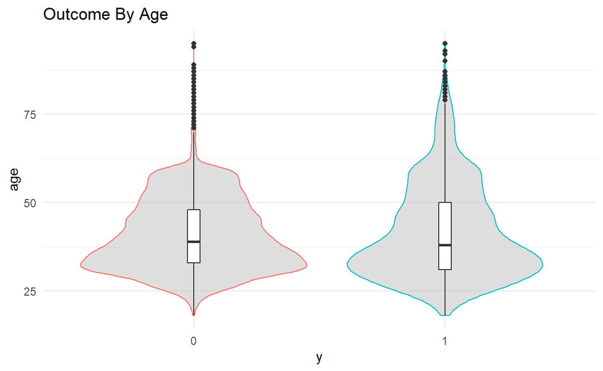

```r
data %>%
  ggplot(aes(x = y, y = age)) +
  geom_violin(aes(color = y), fill = 'grey', alpha=0.5) +
  geom_boxplot(width = 0.05) +
  theme_minimal() +
  theme(legend.position = "none") +
  ggtitle("Outcome By Age")
```

**Continuous Features**

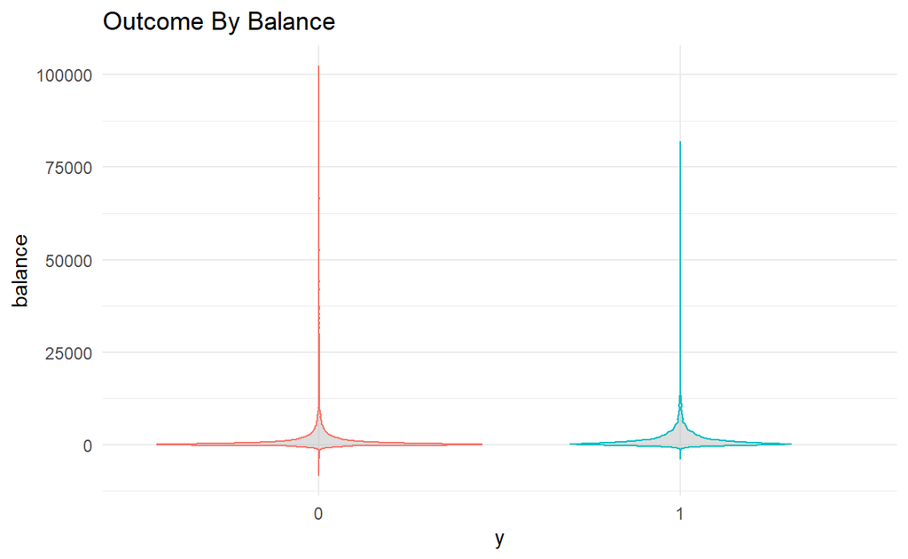

```r
data %>%
  ggplot(aes(x = y, y = balance)) +
  geom_violin(aes(color = y), fill = 'grey', alpha=0.5, trim=F) +
  theme_minimal() +
  theme(legend.position = "none") +
  ggtitle("Outcome By Balance")
```

**Continuous Features**

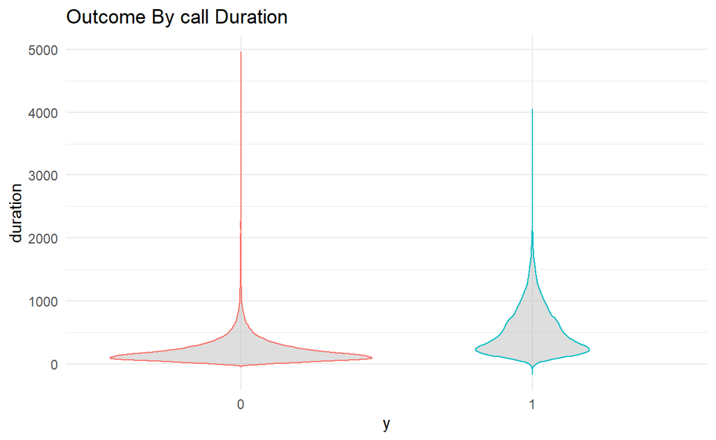

```r
data %>%
  ggplot(aes(x = y, y = duration)) +
  geom_violin(aes(color = y), fill = 'grey', alpha=0.5, trim=F) +
  theme_minimal() +
  theme(legend.position = "none") +
  ggtitle("Outcome By call Duration")
```

The target variable is a binary category, thus a huge advantage is that it’s not possible to have outliers on the predicting variable. Then, by visualizing the distributions of the continuous features, we can see the points representing outliers regarding the respective distributions. However, the outliers on the dependent variables are proportionally equally distributed between both groups of clients. Hence, there is no need to modify those extreme values, which just represent minority groups of the population of this study.

Note that the distribution of subscribed customers ($y=1$), is wider at higher values of age and call duration compared to the other category

**Time Features**

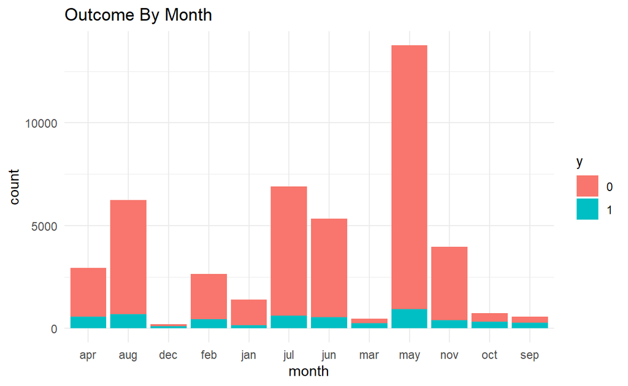

```r
data %>%
  ggplot(aes(month, fill = y)) +
  geom_bar(position = "stack") +
  theme_minimal() +
  ggtitle("Outcome By Month")
```

**Time Features**

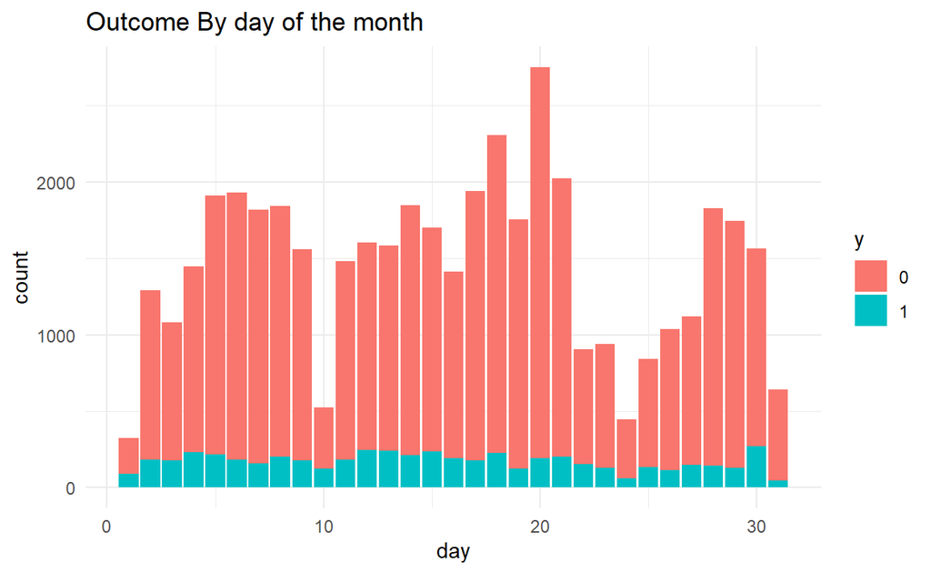

```r
data %>%
  ggplot(aes(day, fill = y)) +
  geom_bar(position = "stack") +
  theme_minimal() +
  ggtitle("Outcome By day of the month")
```

**Binary Features**

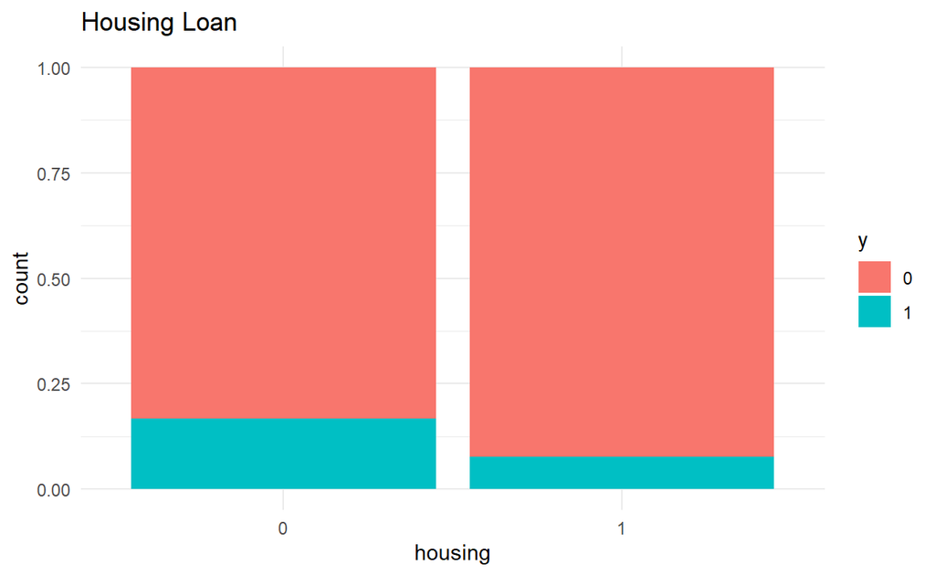

```r
data %>%
  ggplot(aes(housing, fill = y)) +
  geom_bar(position = "fill") +
  theme_minimal() +
  ggtitle("Housing Loan")
```

**Binary Features**

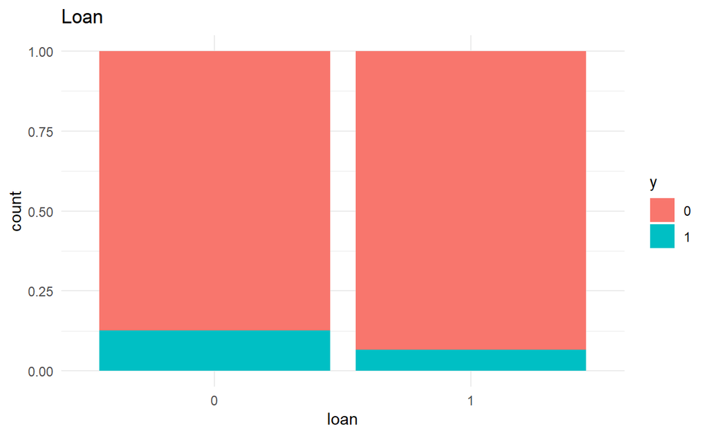

```r
data %>%
  ggplot(aes(loan, fill = y)) +
  geom_bar(position = "fill") +
  theme_minimal() +
  ggtitle("Loan")
```

Customers with loans had lower tendency on subscribing to the term deposit.

Regarding the previous contacts, more than 75% of the customers where not contacted for previous campaigns. The following plot shows the trend of the remaining quantile.

About the previous contacts from the campaign of study, at least 75% of the customers where contacted a maximum of 3 times.

**Previous Contacts**

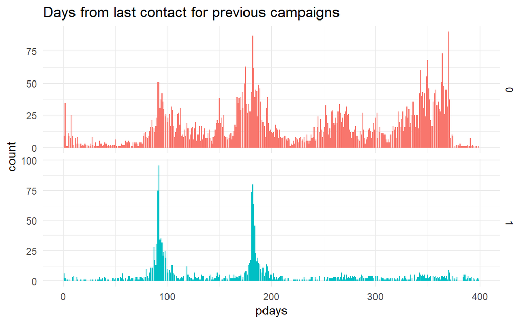

```r
data %>% filter(pdays>=0 & pdays<=400) %>%
  ggplot(aes(pdays, fill = y)) +
  geom_bar(position = "stack") +
  facet_grid(rows = vars(y), scales = "free") +
  theme_minimal() +
  theme(legend.position = "none") +
  ggtitle("Days from last contact for previous campaigns")
```

**Previous Contacts**

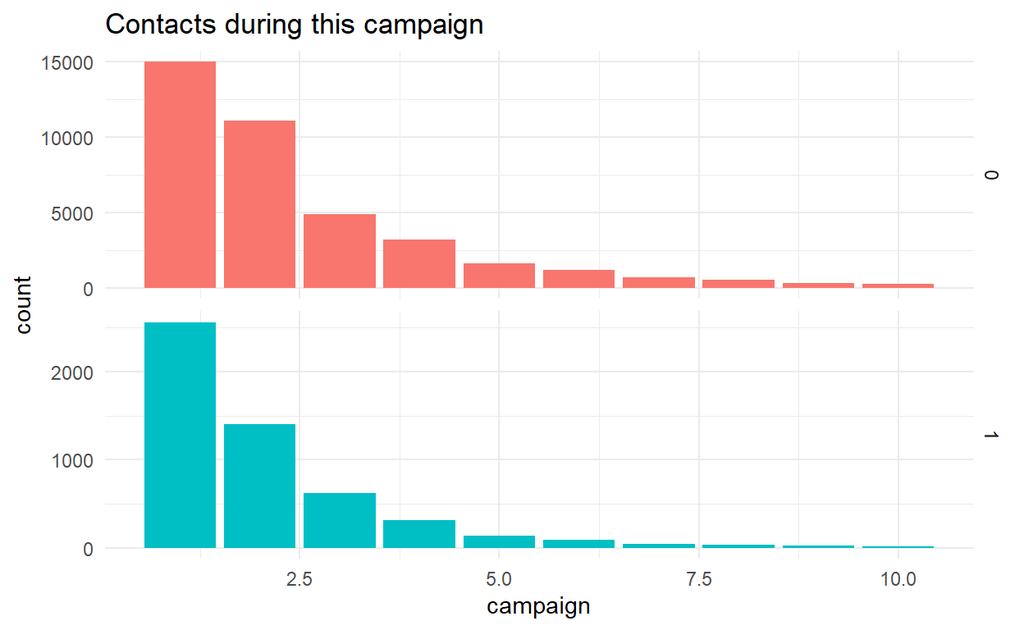

```r
data %>% filter(campaign <= 10) %>%
  ggplot(aes(campaign, fill = y)) +
  geom_bar(position = "stack") +
  facet_grid(rows = vars(y), scales = "free") +
  theme_minimal() +
  theme(legend.position = "none") +
  ggtitle("Contacts during this campaign")
```

# Models

The **target is a binary variable** which can take the values (0,1). Hence, the activation function will be the same in all models, which is going to be the logistic transfer function. This function is continuous so after the training the output values will need to be rounded so that they are either 0 or 1.

Previous to training the models, I’ve processed the features as all input features of an artificial neural network must be numeric. Hence, I’ve transformed the categorical variables into features and subsequently to numbers. Now, the categorical variables still define different categories, yet instead of having a character labels, they have a number.

**Preprocessing**

```r
model_data <- copy %>%
  mutate(across(c(job, marital, education, month, poutcome), as.factor)) %>%
  mutate(across(c(job, marital, education, month, poutcome,
                          default, housing, loan, y), as.numeric))
```

Next step, is to split the data into training and testing in a 70/30 ratio.

**Split**

```r
set.seed(10)
n = nrow(data)
m = ncol(data)
idx = sample(n, n*0.7)
train = model_data[idx, ]
test = model_data[-idx, ]
summary(train); summary(test)
```

```
      age             job            marital        education
 Min.   :18.00   Min.   : 1.000   Min.   :1.000   Min.   :1.000
 1st Qu.:33.00   1st Qu.: 2.000   1st Qu.:2.000   1st Qu.:2.000
 Median :39.00   Median : 5.000   Median :2.000   Median :2.000
 Mean   :40.89   Mean   : 5.343   Mean   :2.168   Mean   :2.225
 3rd Qu.:48.00   3rd Qu.: 8.000   3rd Qu.:3.000   3rd Qu.:3.000
 Max.   :95.00   Max.   :12.000   Max.   :3.000   Max.   :4.000
    default           balance           housing           loan
 Min.   :0.00000   Min.   :-8019.0   Min.   :0.000   Min.   :0.0000
 1st Qu.:0.00000   1st Qu.:   72.5   1st Qu.:0.000   1st Qu.:0.0000
 Median :0.00000   Median :  449.0   Median :1.000   Median :0.0000
 Mean   :0.01795   Mean   : 1352.8   Mean   :0.556   Mean   :0.1598
 3rd Qu.:0.00000   3rd Qu.: 1430.0   3rd Qu.:1.000   3rd Qu.:0.0000
 Max.   :1.00000   Max.   :98417.0   Max.   :1.000   Max.   :1.0000
      day            month           duration         campaign
 Min.   : 1.00   Min.   : 1.000   Min.   :   0.0   Min.   : 1.000
 1st Qu.: 8.00   1st Qu.: 4.000   1st Qu.: 102.0   1st Qu.: 1.000
 Median :16.00   Median : 7.000   Median : 179.0   Median : 2.000
 Mean   :15.84   Mean   : 6.539   Mean   : 257.3   Mean   : 2.749
 3rd Qu.:21.00   3rd Qu.: 9.000   3rd Qu.: 318.0   3rd Qu.: 3.000
 Max.   :31.00   Max.   :12.000   Max.   :4918.0   Max.   :63.000
     pdays           previous          poutcome           y
 Min.   : -1.00   Min.   : 0.0000   Min.   :1.000   Min.   :0.0000
 1st Qu.: -1.00   1st Qu.: 0.0000   1st Qu.:4.000   1st Qu.:0.0000
 Median : -1.00   Median : 0.0000   Median :4.000   Median :0.0000
 Mean   : 40.27   Mean   : 0.5796   Mean   :3.559   Mean   :0.1171
 3rd Qu.: -1.00   3rd Qu.: 0.0000   3rd Qu.:4.000   3rd Qu.:0.0000
 Max.   :871.00   Max.   :58.0000   Max.   :4.000   Max.   :1.0000
```

```
      age             job            marital        education
 Min.   :18.00   Min.   : 1.000   Min.   :1.000   Min.   :1.000
 1st Qu.:33.00   1st Qu.: 2.000   1st Qu.:2.000   1st Qu.:2.000
 Median :39.00   Median : 5.000   Median :2.000   Median :2.000
 Mean   :41.05   Mean   : 5.333   Mean   :2.168   Mean   :2.224
 3rd Qu.:49.00   3rd Qu.: 8.000   3rd Qu.:3.000   3rd Qu.:3.000
 Max.   :95.00   Max.   :12.000   Max.   :3.000   Max.   :4.000
    default           balance          housing            loan
 Min.   :0.00000   Min.   : -6847   Min.   :0.0000   Min.   :0.0000
 1st Qu.:0.00000   1st Qu.:    72   1st Qu.:0.0000   1st Qu.:0.0000
 Median :0.00000   Median :   446   Median :1.0000   Median :0.0000
 Mean   :0.01821   Mean   :  1384   Mean   :0.5554   Mean   :0.1613
 3rd Qu.:0.00000   3rd Qu.:  1419   3rd Qu.:1.0000   3rd Qu.:0.0000
 Max.   :1.00000   Max.   :102127   Max.   :1.0000   Max.   :1.0000
      day            month           duration         campaign
 Min.   : 1.00   Min.   : 1.000   Min.   :   0.0   Min.   : 1.000
 1st Qu.: 8.00   1st Qu.: 4.000   1st Qu.: 105.0   1st Qu.: 1.000
 Median :16.00   Median : 7.000   Median : 183.0   Median : 2.000
 Mean   :15.73   Mean   : 6.485   Mean   : 260.2   Mean   : 2.799
 3rd Qu.:21.00   3rd Qu.: 9.000   3rd Qu.: 322.0   3rd Qu.: 3.000
 Max.   :31.00   Max.   :12.000   Max.   :3881.0   Max.   :58.000
     pdays           previous           poutcome           y
 Min.   : -1.00   Min.   :  0.0000   Min.   :1.000   Min.   :0.0000
 1st Qu.: -1.00   1st Qu.:  0.0000   1st Qu.:4.000   1st Qu.:0.0000
 Median : -1.00   Median :  0.0000   Median :4.000   Median :0.0000
 Mean   : 40.02   Mean   :  0.5819   Mean   :3.563   Mean   :0.1168
 3rd Qu.: -1.00   3rd Qu.:  0.0000   3rd Qu.:4.000   3rd Qu.:0.0000
 Max.   :804.00   Max.   :275.0000   Max.   :4.000   Max.   :1.0000
```

The following table is defined for a learning rate tuning that will be applied to the *backpropagation* models.

**lr_tuning**

```r
a = c("logistic")
lr = c(0.005, 0.01, 0.05, 0.1)
results = matrix(ncol = length(lr), nrow = length(a))
colnames(results) = as.character(lr)
rownames(results) = a
```

I’ll apply a normalization and standarization to some model’s input to compare the performance.

```r
minmax <- function(v){
  return((v - min(v))/(max(v) - min(v)))
}
X_train_norm = apply(train[-m], 2, FUN = minmax)
X_test_norm = apply(test[-m], 2, FUN = minmax)

standardize <- function(x) {
  return((x - mean(x)) / (sd(x)))
}
X_train_std = apply(train[-m], 2, FUN = standardize)
X_test_std = apply(test[-m], 2, FUN = standardize)
```

```r
train_norm = cbind(X_train_norm, train[m])
test_norm = cbind(X_test_norm, test[m])
train_std = cbind(X_train_std, train[m])
test_std = cbind(X_test_std, test[m])
```

### ANN 1

```r
data.frame(Parameter = c("Hidden Layers", "Learning Rate",
                                  "Algorithm", "Activation"),
                    Values = c(1, "tunning", "backprop", "logistic")) %>% paged_table()
```

| Parameter | Values |
| --- | --- |
| Hidden Layers | 1 |
| Learning Rate | tunning |
| Algorithm | backprop |
| Activation | logistic |

**Model1**

```r
for (l in 1:length(lr)){
  set.seed(2805)
  ann1 <- neuralnet(formula = y ~ ., data = train,
                  hidden = c(4), learningrate = lr[l],
                  algorithm = "backprop", act.fct = "logistic",
                  err.fct = "sse",
                  linear.output = F)
  if (is.null(ann1$result.matrix[1])){
    results[a, l] = NA
  }
  else {
    results[a, l] = ann1$result.matrix[1]
  }
}
results %>% as.data.frame() %>% paged_table()
```

|  | 0.005 | 0.01 | 0.05 | 0.1 |
| --- | --- | --- | --- | --- |
| logistic | 1852.5 | 1852.5 | 1852.5 | 1852.5 |

```r
best1 = results[which.min(results)]
ann1 <- neuralnet(formula = y ~ ., data = train,
                  hidden = c(4), learningrate = best1,
                  algorithm = "backprop", act.fct = "logistic",
                  err.fct = "sse",
                  linear.output = F)
pred1 <- compute(ann1, test[-m])
Acc1 = mean(test$y == round(pred1$net.result))
table(round(pred1$net.result), test$y)
```

```
        0     1
  0 11980  1584
```

### Normalized

```r
data.frame(Parameter = c("Hidden Layers", "Learning Rate",
                                  "Algorithm", "Activation",
                         "Processing"),
                    Values = c(3, "tunning", "backprop", "logistic", "normalized")) %>% paged_table()
```

| Parameter | Values |
| --- | --- |
| Hidden Layers | 3 |
| Learning Rate | tunning |
| Algorithm | backprop |
| Activation | logistic |
| Processing | normalized |

**Model2**

```r
set.seed(2805)
for (l in 1:length(lr)){
  ann2 <- neuralnet(formula = y ~ ., data = train_norm,
                  hidden = c(2, 4, 3), learningrate = lr[l],
                  algorithm = "backprop", act.fct = "logistic",
                  err.fct = "sse",
                  linear.output = F)
  if (is.null(ann2$result.matrix[1])){
    results[a, l] = NA
  }
  else {
    results[a, l] = ann2$result.matrix[1]
  }
}
results %>% as.data.frame() %>% paged_table()
```

|  | 0.005 | 0.01 | 0.05 | 0.1 |
| --- | --- | --- | --- | --- |
| logistic | NA | 1852.499 | 1852.5 | 1852.5 |

```r
best2 = results[which.min(results)]
ann2 <- neuralnet(formula = y ~ ., data = train_norm,
                  hidden = c(2, 4, 3), learningrate = best2,
                  algorithm = "backprop", act.fct = "logistic",
                  err.fct = "sse",
                  linear.output = F)
pred2 <- compute(ann2, test_norm[-m])
Acc1 = mean(test$y == round(pred2$net.result))
table(round(pred2$net.result), test$y)
```

```
        0     1
  0 11980  1584
```

### Standarized

```r
data.frame(Parameter = c("Hidden Layers", "Learning Rate",
                                  "Algorithm", "Activation",
                         "Processing"),
                    Values = c(3, "tunning", "backprop", "logistic", "standarized")) %>% paged_table()
```

| Parameter | Values |
| --- | --- |
| Hidden Layers | 3 |
| Learning Rate | tunning |
| Algorithm | backprop |
| Activation | logistic |
| Processing | standarized |

**Model3**

```r
set.seed(2805)
for (l in 1:length(lr)){
  ann3 <- neuralnet(formula = y ~ ., data = train_std,
                  hidden = c(2, 4, 3), learningrate = lr[l],
                  algorithm = "backprop", act.fct = "logistic",
                  err.fct = "sse",
                  linear.output = F)
  if (is.null(ann3$result.matrix[1])){
    results[a, l] = NA
  }
  else {
    results[a, l] = ann3$result.matrix[1]
  }
}
results %>% as.data.frame() %>% paged_table()
```

|  | 0.005 | 0.01 | 0.05 | 0.1 |
| --- | --- | --- | --- | --- |
| logistic | NA | 1852.498 | 1852.5 | 1852.5 |

```r
best3 = results[which.min(results)]
ann3 <- neuralnet(formula = y ~ ., data = train_std,
                  hidden = c(2, 4, 3), learningrate = lr[l],
                  algorithm = "backprop", act.fct = "logistic",
                  err.fct = "sse",
                  linear.output = F)
pred3 <- compute(ann3, test_std[-m])
Acc3 = mean(test$y == round(pred3$net.result))
table(round(pred3$net.result), test$y)
```

```
        0     1
  0 11980  1584
```

Eventhough models 2 and 3 are more complex than the first one, with 3 hidden layers and 9 neurons, and standarized data, the performance of the model is still poor.

### Alternative Algorithms

In this section I’ve tried out two different propagation algorithms, resilient backpropagation and it’s globally convergent version.

```r
data.frame(Parameter = c("Hidden Layers", "Learning Rate",
                                  "Algorithm", "Activation",
                         "Threshold", "Processing"),
                    Values = c(3, 0.3, "resilient backprop", "logistic", 1, "normalized")) %>% paged_table()
```

| Parameter | Values |
| --- | --- |
| Hidden Layers | 3 |
| Learning Rate | 0.3 |
| Algorithm | resilient backprop |
| Activation | logistic |
| Threshold | 1 |
| Processing | normalized |

**Model 4**

```r
set.seed(2805)
ann4 <- neuralnet(formula = y ~ ., data = train_norm,
                  hidden = c(2, 4, 2), learningrate = 0.3,
                  # learningrate.limit = c(0.05, 1),
                  algorithm = "rprop+",
                  # act.fct = "logistic",
                  err.fct = "sse", threshold = 1,
                  linear.output = F)

pred4 <- compute(ann4, test_norm[-m])
Acc4 = mean(test$y == round(pred4$net.result))
table(round(pred4$net.result), test$y)
```

```
        0     1
  0 11345   858
  1   635   726
```

**CM M4**

```r
confusionMatrix(data = as.factor(round(pred4$net.result)),
                reference = as.factor(test$y))
```

```
Confusion Matrix and Statistics

          Reference
Prediction     0     1
         0 11345   858
         1   635   726

               Accuracy : 0.8899
                 95% CI : (0.8845, 0.8951)
    No Information Rate : 0.8832
    P-Value [Acc > NIR] : 0.007413

                  Kappa : 0.4317

 Mcnemar's Test P-Value : 9.168e-09

            Sensitivity : 0.9470
            Specificity : 0.4583
         Pos Pred Value : 0.9297
         Neg Pred Value : 0.5334
             Prevalence : 0.8832
         Detection Rate : 0.8364
   Detection Prevalence : 0.8997
      Balanced Accuracy : 0.7027

       'Positive' Class : 0
```

```r
data.frame(Parameter = c("Hidden Layers", "Learning Rate",
                                  "Algorithm", "Activation",
                         "Threshold", "Processing"),
                    Values = c(3, 0.3, "sag", "logistic", 1, "normalized")) %>% paged_table()
```

| Parameter | Values |
| --- | --- |
| Hidden Layers | 3 |
| Learning Rate | 0.3 |
| Algorithm | sag |
| Activation | logistic |
| Threshold | 1 |
| Processing | normalized |

**Model 5**

```r
set.seed(2805)
ann5 <- neuralnet(formula = y ~ ., data = train_norm,
                  hidden = c(2, 4, 2), learningrate = 0.3,
                  # learningrate.limit = c(0.05, 1),
                  algorithm = "sag",
                  # act.fct = "logistic",
                  err.fct = "sse", threshold = 1,
                  linear.output = F)

pred5 <- compute(ann5, test_norm[-m])
Acc5 = mean(test$y == round(pred5$net.result))
table(round(pred5$net.result), test$y)
```

```
        0     1
  0 11365   834
  1   615   750
```

**CM M5**

```r
confusionMatrix(data = as.factor(round(pred5$net.result)),
                reference = as.factor(test$y))
```

```
Confusion Matrix and Statistics

          Reference
Prediction     0     1
         0 11365   834
         1   615   750

               Accuracy : 0.8932
                 95% CI : (0.8879, 0.8983)
    No Information Rate : 0.8832
    P-Value [Acc > NIR] : 0.0001372

                  Kappa : 0.4491

 Mcnemar's Test P-Value : 1.023e-08

            Sensitivity : 0.9487
            Specificity : 0.4735
         Pos Pred Value : 0.9316
         Neg Pred Value : 0.5495
             Prevalence : 0.8832
         Detection Rate : 0.8379
   Detection Prevalence : 0.8994
      Balanced Accuracy : 0.7111

       'Positive' Class : 0
```

These models have higher execution time and need a high threshold in order to converge. The upside is that are the first models able to predict subscribed customers.

As explained before, the model’s output is a continuous value between 0 and 1. The previous results are assuming that the reference in order to rise to 1 or drop to 0, is 0.5.

### Oversampling

As seen during the EDA, the target variable is heavily unbalanced. Hence, I’ve decided to compensate it by duplicating the observations of the minority group in the training set and then shuffling the whole dataset and training the neural network with the outcome of this process.

This is a common practice for unbalanced data. In the original paper of [Moro et al., 2011](https://core.ac.uk/download/pdf/55616194.pdf), they use this same technique.

**Oversampling**

```r
minority <- train_norm %>% filter(y==1)
train_norm2 <- rbind(train_norm, minority) %>% sample_frac()
data.frame("original" = prop.table(table(train$y)), "oversampled" = prop.table(table(train_norm2$y))) %>% paged_table()
```

| original.Var1 | original.Freq | oversampled.Var1 | oversampled.Freq |
| --- | --- | --- | --- |
| 0 | 0.8829273 | 0 | 0.7903938 |
| 1 | 0.1170727 | 1 | 0.2096062 |

**Model 6**

```r
set.seed(2805)
ann6 <- neuralnet(formula = y ~ ., data = train_norm2,
                  hidden = c(2, 4, 2), learningrate = 0.005,
                  # learningrate.limit = c(0.05, 1),
                  algorithm = "backprop", act.fct = "logistic",
                  err.fct = "sse",
                  # threshold = 1,
                  linear.output = F)
 # ann4$result.matrix[1]
pred6 <- compute(ann6, test_norm[-m])
Acc6 = mean(test$y == round(pred6$net.result))
table(round(pred6$net.result), test$y)
```

```
        0     1
  0 11980  1584
```

### Undersampling

During the EDA I’ve seen that many descriptive features contain some outliers. In this section I’ve analyzed the outliers in order to detect if target variable has de same distribution on the extreme values. Lastly, I’ve filtered the observation in order to, removing some outliers, increase the proportion of the minority group($y=1$).

```r
# data %>% filter(balance >= 1500) %>% select(y) %>% table() %>% prop.table()
#
# data %>% filter(duration > 4000 | duration < 100) %>% select(y) %>% table() %>% prop.table()
#
# data %>% filter(pdays > 400) %>% select(y) %>% table() %>% prop.table()
#
# data %>% filter(campaign >= 9) %>% select(y) %>% table() %>% prop.table()
#
# data %>% filter(job == "blue-collar") %>% select(y) %>% table() %>% prop.table()

undersamp_data <- copy %>% filter(balance <= 15000, duration <= 4000 & duration > 100,
                pdays <= 400, campaign <= 9, job != "blue-collar")

undersamp_data$y %>% table() %>% prop.table()
```

```
.
        0         1
0.8353558 0.1646442
```

**Preprocessing**

```r
model_data2 <- undersamp_data %>%
  mutate(across(c(job, marital, education, month, poutcome), as.factor)) %>%
  mutate(across(c(job, marital, education, month, poutcome,
                          default, housing, loan, y), as.numeric))
```

Next step, is to split the new set into training and testing in a 70/30 ratio.

**Split**

```r
set.seed(2805)
n = nrow(undersamp_data)
idx = sample(n, n*0.7)
train3 = model_data2[idx, ]
test3 = model_data2[-idx, ]
X_train_norm3 = apply(train3[-m], 2, FUN = minmax)
X_test_norm3 = apply(test3[-m], 2, FUN = minmax)
train_norm3 = cbind(X_train_norm3, train3$y)
test_norm3 = cbind(X_test_norm3, test3$y)
```

**Model 7**

```r
set.seed(2805)
ann7 <- neuralnet(formula = y ~ ., data = train3,
                  hidden = c(2, 4, 2), learningrate = 0.01,
                  # learningrate.limit = c(0.05, 1),
                  algorithm = "backprop", act.fct = "logistic",
                  err.fct = "sse", threshold = 0.0001,
                  linear.output = F)

pred7 <- compute(ann7, test[-m])
Acc7 = mean(test$y == round(pred7$net.result))
table(round(pred7$net.result), test$y)
```

```
        0     1
  0 11980  1584
```

## Best Model

Model 5, has been the best performing one. Hence, as the last section of the project I’ve evaluate the precision of Model 5 this time with a cross validation over the whole dataset in order to have a more realistic approach.

**Best Model**

```r
cv.accuracy <- NULL
k <- 5

## to cotrol the process
library(plyr)
pbar <- create_progress_bar('text')
pbar$init(k)
```

**Best Model**

```r
set.seed(2805)
## the loop to implement cross validation
for(i in 1:k){
    index <- sample(1:n, round(0.7*n))
    trainset.cv <- model_data[index,]
    testset.cv <- model_data[-index,]
    train_norm.cv = apply(trainset.cv, 2, FUN = minmax) %>% as.data.frame()
    test_norm.cv = apply(testset.cv, 2, FUN = minmax) %>% as.data.frame()

    ANN.CV <- neuralnet(formula = y ~ ., data = train_norm.cv,
                  hidden = c(2, 4, 2), learningrate = 0.3,
                  # learningrate.limit = c(0.05, 1),
                  algorithm = "sag",
                  # act.fct = "logistic",
                  err.fct = "sse", threshold = 0.3,
                  linear.output = F)

    pr.ANN.cv <- compute(ANN.CV, test_norm.cv[,-m])

    ntest <- length(test_norm.cv)
    cv.accuracy[i] <- mean(test_norm.cv[,m] == round(pr.ANN.cv$net.result))

    pbar$step()
}
```

**Best Model**

```r
cv.accuracy
```

```
[1] 0.8373521 0.8399408 0.8375370 0.8371302 0.8368343
```

**Best Model**

```r
## Average acurracy
mean(cv.accuracy)
```

```
[1] 0.8377589
```

**Best Model**

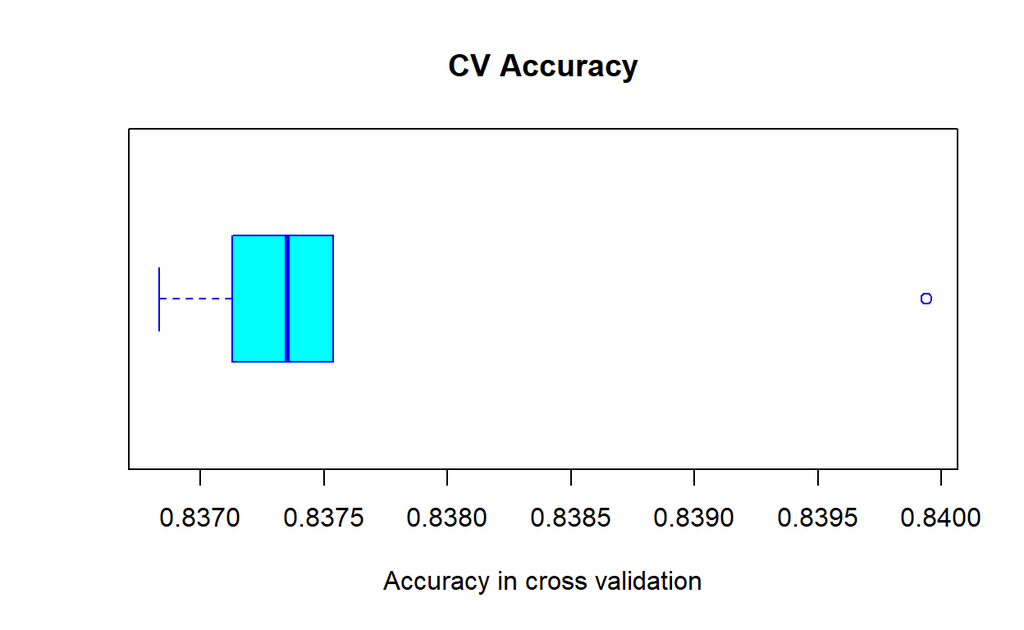

```r
## Boxplot of the MSE error
boxplot(cv.accuracy, xlab='Accuracy in cross validation',col='cyan',
        border='blue',names='CV Accuracy',
        main='CV Accuracy',horizontal=TRUE)
```

# Conclusion

Right from the beginning of the analysis the huge disproportion of the target variable is a clear fact. Moreover, during the EDA we can tell that there is not a clear predisposition from the target groups towards any of the features’ categories or range of values, the distributions are quite similar for both target groups. This made it extremely difficult for the models to classify the observation properly. Many methods have been used, with original, normalize and standardized data, applying distinct propagation algorithms, and finally trying to balance the data with oversampling and undersampling. However, any of the models had succeeded at identifying the hidden pattern that devides the two target groups. For future analysis I would suggest to add new variables, also may be removing some of the existing variables could avoid part of the noise. In addition, a combination of artificial neural networks with other algorithms such as SVM could help find a solution to this classification problem.

# References

[Moro et al., 2011] **S. Moro, R. Laureano and P. Cortez.** *Using Data Mining for Bank Direct Marketing: An Application of the CRISP-DM Methodology.* In P. Novais et al. (Eds.), Proceedings of the European Simulation and Modelling Conference - ESM’2011, pp. 117-121, Guimarães, Portugal, October, 2011. EUROSIS.

[Term Deposit, Fixed Income Essentials, Incesopedia](https://www.investopedia.com/terms/t/termdeposit.asp)